# ADA Project- Weapon carrying and victims of bullying

Nkiru Obi

11/3/2021

I used Youth Risk Behavioral Surveillance (YRBS) 2019 data compiled by the CDC.

# Data source:

- https://www.cdc.gov/healthyyouth/data/yrbs/files/2019/XXH2019_YRBS_Data.dat

# Sample characteristics

- collected in 2019.
- sample size= 13677.
- 6 variables: all factor variables

# Research question

- HOW DID WEAPON CARRYING IN SCHOOL DIFFER BETWEEN BULLIED AND NONBULLIED HIGH SCHOOL STUDENTS IN THE UNITED STATES IN 2019.

# Logistic regression purpose

- Logistic regression was used to predict the probability of the outcome variable, weapon carrying to school.
- In this case, we are determining whether the predictor variable- victimization help predict weapon carrying to school.
- The outcome variable, weapon carrying, is a categorical variable recoded with 2 categories (binary variable): did not carry weapon (0) and carried weapon (1).
- Because outcome is binary, the model predicts probability of being in one of the two categories.
- I would be adjusting for age, sex, grade, and sexual identity as confounders as identified by Directed Acyclic Graph (DAG).

## Codebook:

```r
#Load packages
pacman::p_load(tidyverse, foreign, haven, survey, ROCR, odds.n.ends, blorr, lmtest, car)

#Read in data
yrbs_2019 <- read.spss(
    "C:/Users/nkiru/Documents/NKYRUH/Advanced Data Analysis/Git_ADA_Project/yrbs2019.sav", to.data.frame = TRUE)
```

```r
#Select variables of interest into smaller dataframe called yrbss and rename variables.
yrbss <- yrbs_2019 %>%
  select(Q1, Q2, Q3, Q66, Q23, Q13, weight, stratum, psu) %>%
  rename(age = Q1, sex= Q2, grade= Q3, sexual_identity= Q66, bully_victim= Q23, weapon_carrying= Q13)

#check data
summary(yrbss)
```

```
##                     age           sex                           grade
##  16 years old         :3628   Female:6885   9th grade              :3637
##  15 years old         :3473   Male  :6641   10th grade             :3717
##  17 years old         :3102   NA's  : 151   11th grade             :3322
##  14 years old         :1699                 12th grade             :2850
##  18 years old or older:1616                 Ungraded or other grade:  39
##  (Other)              :  87                 NA's                   : 112
##  NA's                 :  72
##                 sexual_identity  bully_victim       weapon_carrying
##  Heterosexual (straight):10853   Yes : 2703   0 days        :12509
##  Gay or lesbian         :  380   No  :10744   1 day         :  126
##  Bisexual               : 1151   NA's:  230   2 or 3 days   :   68
##  Not sure               :  591                4 or 5 days   :   36
##  NA's                   :  702                6 or more days:  162
##                                               NA's          :  776
##
##      weight          stratum           psu
##  Min.   :0.0650   Min.   :101.0   Min.   : 57923
##  1st Qu.:0.3315   1st Qu.:103.0   1st Qu.:173676
##  Median :0.7480   Median :201.0   Median :343880
##  Mean   :1.0000   Mean   :158.6   Mean   :364603
##  3rd Qu.:1.3605   3rd Qu.:211.0   3rd Qu.:515957
##  Max.   :4.8641   Max.   :214.0   Max.   :787890
##
```

```r
#check the class of the variables
sapply(yrbss, class)
```

```
##             age             sex           grade sexual_identity    bully_victim
##        "factor"        "factor"        "factor"        "factor"        "factor"
## weapon_carrying          weight         stratum             psu
##        "factor"       "numeric"       "numeric"       "numeric"
```

```r
#recode weapon carrying into 2 levels and rename them
yrbss$weapon_carrying <- if_else(yrbss$weapon_carrying== '0 days', 0, 1)
yrbss$weapon_carrying <- factor(yrbss$weapon_carrying, levels = c(0,1), labels = c('did not carry weapon', 'carried weapon'))
table(yrbss$weapon_carrying, useNA = "ifany")
```

```
##
## did not carry weapon       carried weapon                 <NA>
##                12509                  392                  776
```

```r
#relevel bully_victim
yrbss$bully_victim <- if_else(yrbss$bully_victim== 'No', 0, 1)
yrbss$bully_victim <- factor(yrbss$bully_victim, levels = c(0,1), labels = c('No', 'Yes'))

#change age and sexual identity to character variables
yrbss$age = as.character(yrbss$age)
yrbss$sexual_identity = as.character(yrbss$sexual_identity)

#Some data cleaning and drop missing values
yrbss1 <- yrbss %>%
  mutate(age= parse_number(age)) %>%
  mutate(grade= na_if(x= grade, y= 'Ungraded or other grade')) %>%
  mutate(grade= droplevels(x= grade)) %>%
  mutate(sexual_identity= case_when(sexual_identity== 'Not sure'~ 'questioning', TRUE ~ as.character(sexual_identity))) %>%
  mutate(sexual_identity= as.factor(sexual_identity)) %>%
  mutate(weapon_carrying= as.factor(weapon_carrying)) %>%
  drop_na()

#check the class of the variables
sapply(yrbss1, class)
```

```
##             age             sex           grade sexual_identity    bully_victim
##       "numeric"        "factor"        "factor"        "factor"        "factor"
## weapon_carrying          weight         stratum             psu
##        "factor"       "numeric"       "numeric"       "numeric"
```

```r
# Check dataset
summary(object = yrbss1)
```

```
##       age            sex              grade
##  Min.   :12.00   Female:6106   9th grade :3182
##  1st Qu.:15.00   Male  :5815   10th grade:3345
##  Median :16.00                 11th grade:2871
##  Mean   :15.94                 12th grade:2523
##  3rd Qu.:17.00
##  Max.   :18.00
##                 sexual_identity  bully_victim             weapon_carrying
##  Bisexual               : 1054   No :9594     did not carry weapon:11629
##  Gay or lesbian         :  322   Yes:2327     carried weapon      :  292
##  Heterosexual (straight):10040
##  questioning            :  505
##
##
##      weight          stratum           psu
##  Min.   :0.0650   Min.   :101.0   Min.   : 57923
##  1st Qu.:0.3173   1st Qu.:103.0   1st Qu.:173676
##  Median :0.7422   Median :201.0   Median :343880
##  Mean   :0.9976   Mean   :158.2   Mean   :364361
##  3rd Qu.:1.3694   3rd Qu.:211.0   3rd Qu.:515957
##  Max.   :4.8641   Max.   :214.0   Max.   :787890
```

```r
#Look at the rate of missingness
missingRate <- 1- nrow(yrbss1)/nrow(yrbss)
missingRate
```

```
## [1] 0.1283907
```

From the calculation of the rate of missingness, 12.8% (1756) of our cases have missing values on one or more of our variables and were excluded.

```r
#Weighted prevalence of victimization and weapon carrying in the sample
yrbsDesign <- svydesign(id=~psu, weight=~weight,
strata=~stratum,data=yrbss1, nest=TRUE)

svymean(~age + sex + grade+ sexual_identity + bully_victim + weapon_carrying, yrbsDesign)
```

```
##                                             mean     SE
## age                                    16.022993 0.0276
## sexFemale                               0.495509 0.0081
## sexMale                                 0.504491 0.0081
## grade9th grade                          0.262126 0.0063
## grade10th grade                         0.255765 0.0047
## grade11th grade                         0.243345 0.0049
## grade12th grade                         0.238763 0.0067
## sexual_identityBisexual                 0.085984 0.0033
## sexual_identityGay or lesbian           0.023847 0.0021
## sexual_identityHeterosexual (straight)  0.847812 0.0046
## sexual_identityquestioning              0.042356 0.0028
## bully_victimNo                          0.811030 0.0075
## bully_victimYes                         0.188970 0.0075
## weapon_carryingdid not carry weapon     0.976722 0.0026
## weapon_carryingcarried weapon           0.023278 0.0026
```

From the weighted results above, the prevalence of victimization in the sample is 18.9% while the prevalence of weapon carrying to school is 2.3%.

## Figure 1: Graphs of all variables

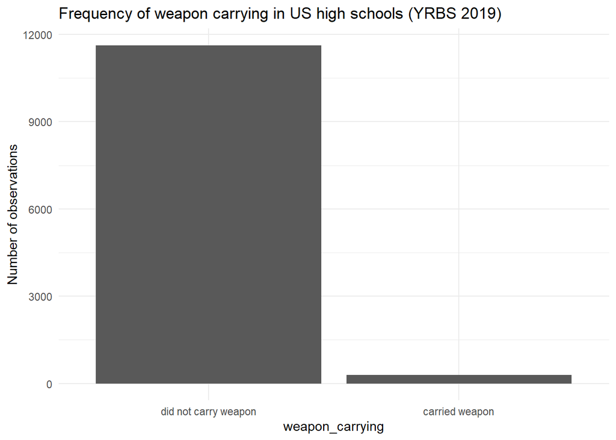

```r
# make graphs of variables
# 1) Weapon carrying
yrbss1 %>%
  ggplot(aes(x = weapon_carrying)) +
  geom_bar() +
  labs(x = "weapon_carrying", y = "Number of observations",
       title = "Frequency of weapon carrying in US high schools (YRBS 2019)") +
  theme_minimal()
```

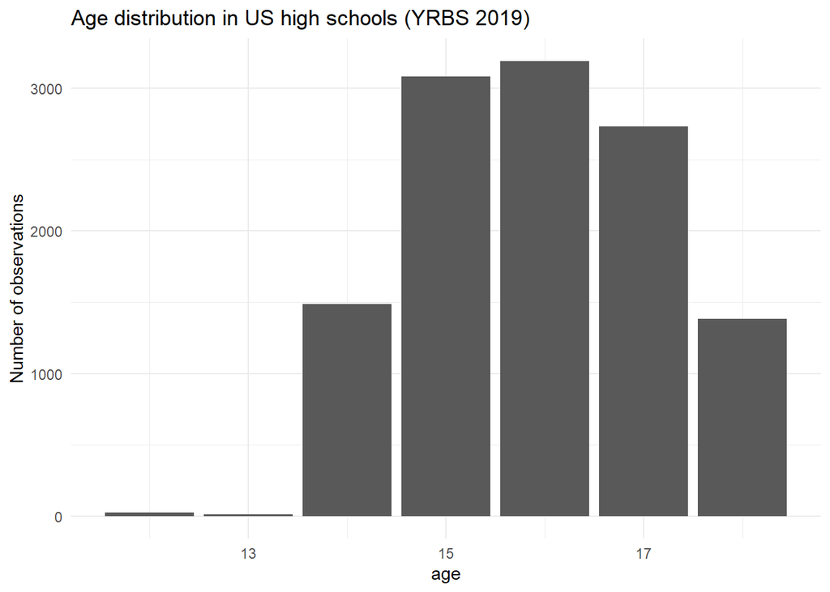

```r
# 2) Age
yrbss1 %>%
  ggplot(aes(x = age)) +
  geom_bar() +
  labs(x = "age", y = "Number of observations",
       title = "Age distribution in US high schools (YRBS 2019)") +
  scale_fill_brewer(palette = "Pastel2", guide = FALSE) +
  theme_minimal()
```

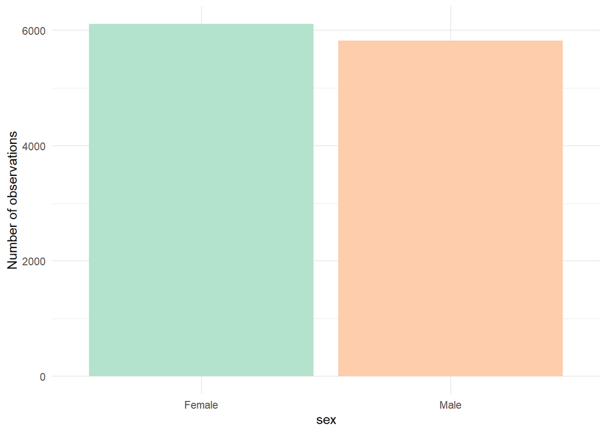

```r
# 3) Sex
yrbss1 %>%
  ggplot(aes(x = sex, fill= sex)) +
  geom_bar() +
  labs(x = "sex", y = "Number of observations") +
  scale_fill_brewer(palette = "Pastel2", guide = FALSE) +
  theme_minimal()
```

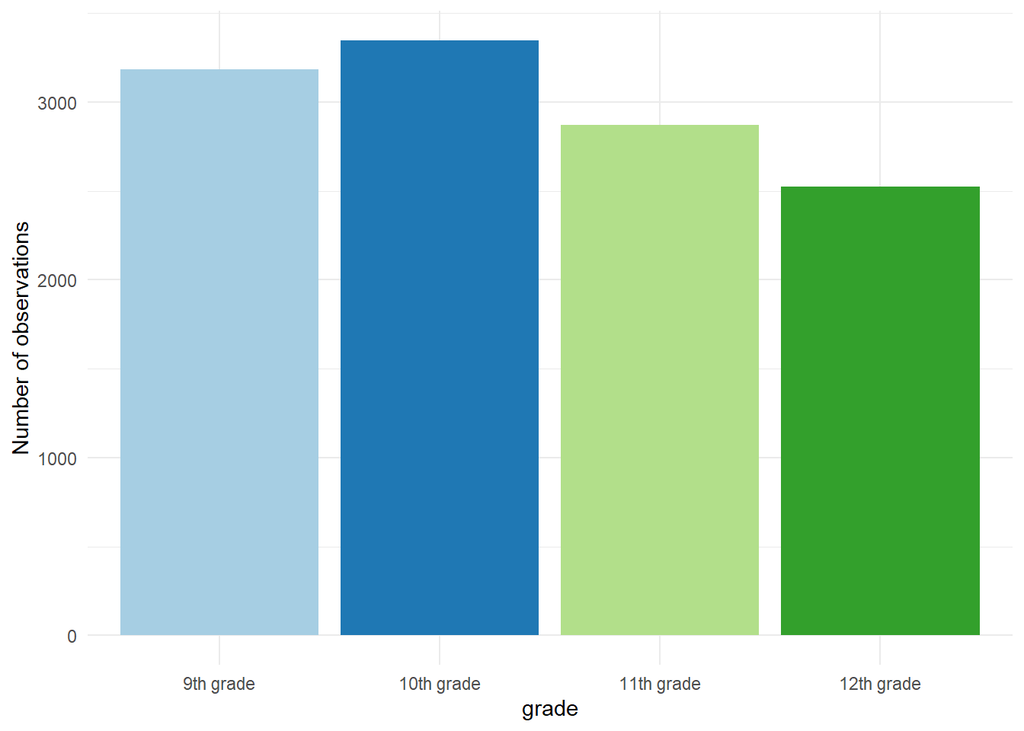

```r
# 4) Grade
yrbss1 %>%
  ggplot(aes(x = grade, fill = grade)) +
  geom_bar() +
  labs(x = "grade", y = "Number of observations") +
  scale_fill_brewer(palette = "Paired", guide = FALSE) +
  theme_minimal()
```

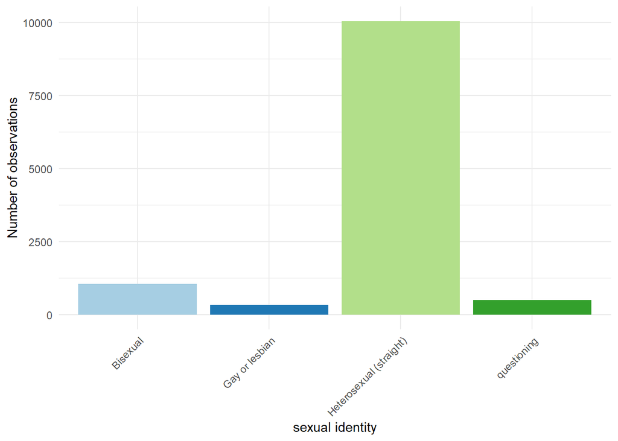

```r
# 5) Sexual identity
yrbss1 %>%
  ggplot(aes(x = sexual_identity, fill = sexual_identity)) +
  geom_bar() +
  labs(x = "sexual identity", y = "Number of observations") +
  scale_fill_brewer(palette = "Paired", guide = FALSE) +
  theme_minimal() +
  theme(axis.text.x = element_text(angle = 45, hjust = 1))
```

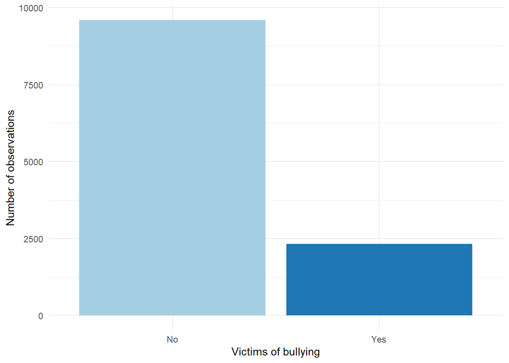

```r
# 6) Bully_victim
yrbss1 %>%
  ggplot(aes(x = bully_victim, fill = bully_victim)) +
  geom_bar() +
  labs(x = "Victims of bullying", y = "Number of observations") +
  scale_fill_brewer(palette = "Paired", guide = FALSE) +
  theme_minimal()
```

## Table 1: Characteristics of participants

```r
library(package= "tableone")
summary.table <- CreateTableOne(data = yrbss1)
print(summary.table, showAllLevels = TRUE)
```

```
##
##                       level                   Overall
##   n                                               11921
##   age (mean (SD))                                 15.94 (1.22)
##   sex (%)             Female                       6106 (51.2)
##                       Male                         5815 (48.8)
##   grade (%)           9th grade                    3182 (26.7)
##                       10th grade                   3345 (28.1)
##                       11th grade                   2871 (24.1)
##                       12th grade                   2523 (21.2)
##   sexual_identity (%) Bisexual                     1054 ( 8.8)
##                       Gay or lesbian                322 ( 2.7)
##                       Heterosexual (straight)     10040 (84.2)
##                       questioning                   505 ( 4.2)
##   bully_victim (%)    No                           9594 (80.5)
##                       Yes                          2327 (19.5)
##   weapon_carrying (%) did not carry weapon        11629 (97.6)
##                       carried weapon                292 ( 2.4)
##   weight (mean (SD))                               1.00 (0.90)
##   stratum (mean (SD))                            158.21 (50.73)
##   psu (mean (SD))                             364360.86 (183358.24)
```

## Figure 2: Graph showing the prevalence of weapon carrying.

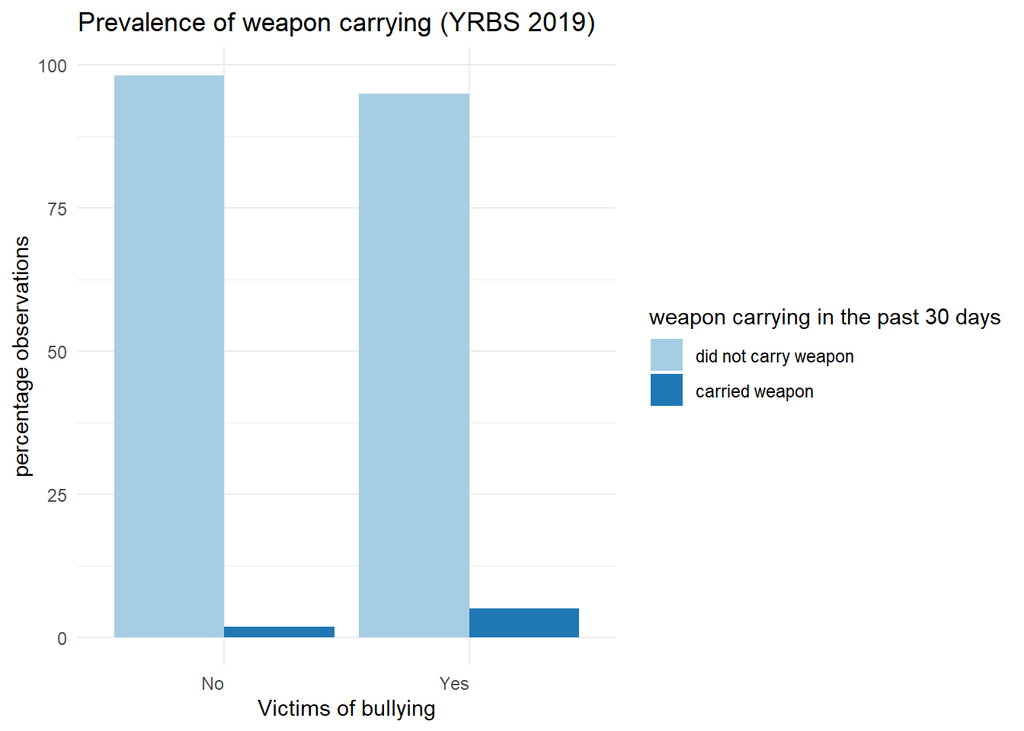

```r
#Examine if there are differences in weapon carrying by bullying victim status
yrbss1 %>%
  group_by(weapon_carrying, bully_victim) %>%
  count() %>%
  group_by(bully_victim) %>%
  mutate(percent= 100* (n/sum(n))) %>%
  ggplot(aes(x=  bully_victim, y= percent, fill = weapon_carrying)) +
  geom_bar(position = "dodge", stat = "identity") +
  labs(x = "Victims of bullying", y = "percentage observations",
       title = "Prevalence of weapon carrying (YRBS 2019)") +
  theme_minimal() +
  scale_fill_brewer(palette = "Paired", name = "weapon carrying in the past 30 days") +
  theme(axis.text.x = element_text(hjust = 1))
```

## Table 2: Descriptive statistics of variables by weapon carrying

```r
#create table of descriptive statistics by weapon carrying status.
library(package= "tableone")

Descriptive <- CreateTableOne(data = yrbss1,
                            strata = 'weapon_carrying',
                            vars = c('age', 'sex', 'grade', 'sexual_identity', 'bully_victim'))
print(Descriptive, showAllLevels = TRUE,
      nonnormal = c('age'))
```

```
##                      Stratified by weapon_carrying
##                       level                   did not carry weapon
##   n                                           11629
##   age (median [IQR])                          16.00 [15.00, 17.00]
##   sex (%)             Female                   6017 (51.7)
##                       Male                     5612 (48.3)
##   grade (%)           9th grade                3128 (26.9)
##                       10th grade               3254 (28.0)
##                       11th grade               2785 (23.9)
##                       12th grade               2462 (21.2)
##   sexual_identity (%) Bisexual                 1015 ( 8.7)
##                       Gay or lesbian            308 ( 2.6)
##                       Heterosexual (straight)  9833 (84.6)
##                       questioning               473 ( 4.1)
##   bully_victim (%)    No                       9419 (81.0)
##                       Yes                      2210 (19.0)
##                      Stratified by weapon_carrying
##                       carried weapon       p      test
##   n                     292
##   age (median [IQR])  16.00 [15.00, 17.00]  0.155 nonnorm
##   sex (%)                89 (30.5)         <0.001
##                         203 (69.5)
##   grade (%)              54 (18.5)          0.007
##                          91 (31.2)
##                          86 (29.5)
##                          61 (20.9)
##   sexual_identity (%)    39 (13.4)         <0.001
##                          14 ( 4.8)
##                         207 (70.9)
##                          32 (11.0)
##   bully_victim (%)      175 (59.9)         <0.001
##                         117 (40.1)
```

## Logistic model for victim of bullying

```r
table(yrbss1$weapon_carrying, yrbss1$bully_victim)
```

```
##
##                          No  Yes
##   did not carry weapon 9419 2210
##   carried weapon        175  117
```

```r
#check levels
levels(yrbss1$weapon_carrying)
```

```
## [1] "did not carry weapon" "carried weapon"
```

```r
levels(yrbss1$bully_victim)
```

```
## [1] "No"  "Yes"
```

```r
#logistic model with bully_victim as a predictor
victimModel <- glm(weapon_carrying ~ bully_victim , data=yrbss1, family="binomial")
summary(victimModel)
```

```
##
## Call:
## glm(formula = weapon_carrying ~ bully_victim, family = "binomial",
##     data = yrbss1)
##
## Deviance Residuals:
##     Min       1Q   Median       3Q      Max
## -0.3212  -0.1919  -0.1919  -0.1919   2.8299
##
## Coefficients:
##                 Estimate Std. Error z value Pr(>|z|)
## (Intercept)     -3.98570    0.07628 -52.249   <2e-16 ***
## bully_victimYes  1.04712    0.12173   8.602   <2e-16 ***
## ---
## Signif. codes:  0 '***' 0.001 '**' 0.01 '*' 0.05 '.' 0.1 ' ' 1
##
## (Dispersion parameter for binomial family taken to be 1)
##
##     Null deviance: 2743.0  on 11920  degrees of freedom
## Residual deviance: 2675.9  on 11919  degrees of freedom
## AIC: 2679.9
##
## Number of Fisher Scoring iterations: 6
```

```r
#calculate and print ORs and 95% CIs
ORbully_victim <-exp(cbind(OR = coef(victimModel), confint(victimModel)))
ORbully_victim
```

```
##                         OR      2.5 %     97.5 %
## (Intercept)     0.01857947 0.01594012 0.02150059
## bully_victimYes 2.84944530 2.24010631 3.61192389
```

```r
odds.n.ends(victimModel)
```

```
## $`Logistic regression model significance`
## Chi-squared        d.f.           p
##      67.082           1       <.001
##
## $`Contingency tables (model fit): frequency predicted`
##                 Number observed
## Number predicted     1     0   Sum
##              1       0     0     0
##              0     292 11629 11921
##              Sum   292 11629 11921
##
## $`Count R-squared (model fit): percent correctly predicted`
## [1] 97.55054
##
## $`Model sensitivity`
## [1] 0
##
## $`Model specificity`
## [1] 1
##
## $`Predictor odds ratios and 95% CI`
##                         OR      2.5 %     97.5 %
## (Intercept)     0.01857947 0.01594012 0.02150059
## bully_victimYes 2.84944530 2.24010631 3.61192389
```

From our model above, those who were victims of bullying had 2.85 times greater odds of carrying weapons to school than those who were not bullied.This was statistically significant [OR= 2.85, CI: 2.24,3.61]. This model correctly predicted 97.55% of our observations. However, model sensitivity was low at 0. This may be due to the small number of observations with weapon carrying compared to the total observations in the dataset.Specificity was 100%, the model was good at predicting those who did not carry weapons.

##Test assumptions of Independence of observations and influence

*Independence of observations* The survey uses a 3-stage cluster sampling method to select students from a class to interview. It is likely that students in a class may be similar and so, observations may not be completely independent.

*Influence*

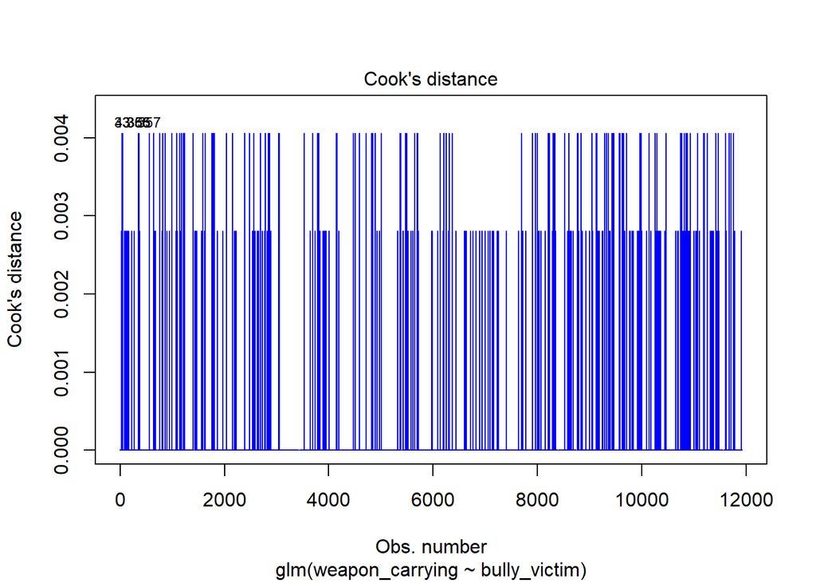

```r
#influence plot - Cook's D plot-identifies observation number in parent dataset
plot(victimModel, which=4, id.n=5, col="blue")
```

*Model Fits*

```r
#Various pseudo R squares, log likelihood, deviance, AIC, BIC
blr_model_fit_stats(victimModel)
```

```
##                                Model Fit Statistics
## -----------------------------------------------------------------------------------
## Log-Lik Intercept Only:     -1371.511    Log-Lik Full Model:              -1337.970
## Deviance(11919):             2675.940    LR(1):                              67.082
##                                          Prob > LR:                           0.000
## MCFadden's R2                   0.024    McFadden's Adj R2:                   0.023
## ML (Cox-Snell) R2:              0.006    Cragg-Uhler(Nagelkerke) R2:          0.027
## McKelvey & Zavoina's R2:        0.050    Efron's R2:                          0.007
## Count R2:                       0.976    Adj Count R2:                        0.000
## BIC:                         2694.712    AIC:                              2679.940
## -----------------------------------------------------------------------------------
```

```r
#Hosmer lemeshow goodness of fit test: a significant p value indicates a bad fit
blr_test_hosmer_lemeshow(victimModel)
```

```
##            Partition for the Hosmer & Lemeshow Test
## --------------------------------------------------------------
##                         def = 1                 def = 0
## Group    Total    Observed    Expected    Observed    Expected
## --------------------------------------------------------------
##   1      9594       175        175.00       9419      9419.00
##   9      2327       117        117.00       2210      2210.00
##  NA       NA         NA          NA          NA          NA
##  NA       NA         NA          NA          NA          NA
##  NA       NA         NA          NA          NA          NA
##  NA       NA         NA          NA          NA          NA
##  NA       NA         NA          NA          NA          NA
##  NA       NA         NA          NA          NA          NA
##  NA       NA         NA          NA          NA          NA
##  NA       NA         NA          NA          NA          NA
## --------------------------------------------------------------
##
##      Goodness of Fit Test
## ------------------------------
## Chi-Square    DF    Pr > ChiSq
## ------------------------------
##   0.0000      8       1.0000
## ------------------------------
```

The Hosmer & lemeshow goodness of fit test has a non-significant p-value (1.000) indicating that our model is a good fit.

## Multivariable model with weapon carrying as the dependent variable and age, sex, grade, and sexual identity as the independent variables

```r
#relevel sexual identity to make Heterosexual the refernce level
levels(yrbss1$sexual_identity)
```

```
## [1] "Bisexual"                "Gay or lesbian"
## [3] "Heterosexual (straight)" "questioning"
```

```r
yrbss1$sexual_identity <- relevel(yrbss1$sexual_identity, ref = 'Heterosexual (straight)')

#Logistic model with confounders
confModel <- glm(weapon_carrying ~ bully_victim + age + sex + grade + sexual_identity, data=yrbss1, family="binomial")
summary(confModel)
```

```
##
## Call:
## glm(formula = weapon_carrying ~ bully_victim + age + sex + grade +
##     sexual_identity, family = "binomial", data = yrbss1)
##
## Deviance Residuals:
##     Min       1Q   Median       3Q      Max
## -1.2080  -0.2349  -0.1938  -0.1287   3.3057
##
## Coefficients:
##                               Estimate Std. Error z value Pr(>|z|)
## (Intercept)                   -1.75120    1.26605  -1.383 0.166603
## bully_victimYes                1.11837    0.12644   8.845  < 2e-16 ***
## age                           -0.24722    0.08644  -2.860 0.004238 **
## sexMale                        1.21296    0.13662   8.878  < 2e-16 ***
## grade10th grade                0.72610    0.19626   3.700 0.000216 ***
## grade11th grade                1.13418    0.24477   4.634 3.59e-06 ***
## grade12th grade                1.16479    0.31562   3.691 0.000224 ***
## sexual_identityBisexual        0.85366    0.18946   4.506 6.61e-06 ***
## sexual_identityGay or lesbian  0.69089    0.28939   2.387 0.016967 *
## sexual_identityquestioning     1.29332    0.20232   6.392 1.63e-10 ***
## ---
## Signif. codes:  0 '***' 0.001 '**' 0.01 '*' 0.05 '.' 0.1 ' ' 1
##
## (Dispersion parameter for binomial family taken to be 1)
##
##     Null deviance: 2743.0  on 11920  degrees of freedom
## Residual deviance: 2536.8  on 11911  degrees of freedom
## AIC: 2556.8
##
## Number of Fisher Scoring iterations: 7
```

```r
#calculate and print ORs and 95% CIs
ORconfModel<-exp(cbind(OR = coef(confModel), confint(confModel)))
ORconfModel
```

```
##                                      OR      2.5 %    97.5 %
## (Intercept)                   0.1735663 0.01404177 2.0191534
## bully_victimYes               3.0598524 2.38374834 3.9148431
## age                           0.7809702 0.66029835 0.9270116
## sexMale                       3.3634144 2.58337279 4.4159299
## grade10th grade               2.0670013 1.41108118 3.0493503
## grade11th grade               3.1086150 1.92438004 5.0291980
## grade12th grade               3.2052505 1.72152331 5.9409939
## sexual_identityBisexual       2.3482210 1.60054979 3.3698708
## sexual_identityGay or lesbian 1.9954866 1.08341769 3.3963111
## sexual_identityquestioning    3.6448496 2.41208275 5.3444116
```

```r
odds.n.ends(confModel)
```

```
## $`Logistic regression model significance`
## Chi-squared        d.f.           p
##     206.224           9       <.001
##
## $`Contingency tables (model fit): frequency predicted`
##                 Number observed
## Number predicted     1     0   Sum
##              1       1     1     2
##              0     291 11628 11919
##              Sum   292 11629 11921
##
## $`Count R-squared (model fit): percent correctly predicted`
## [1] 97.55054
##
## $`Model sensitivity`
## [1] 0.003424658
##
## $`Model specificity`
## [1] 0.999914
##
## $`Predictor odds ratios and 95% CI`
##                                      OR      2.5 %    97.5 %
## (Intercept)                   0.1735663 0.01404177 2.0191534
## bully_victimYes               3.0598524 2.38374834 3.9148431
## age                           0.7809702 0.66029835 0.9270116
## sexMale                       3.3634144 2.58337279 4.4159299
## grade10th grade               2.0670013 1.41108118 3.0493503
## grade11th grade               3.1086150 1.92438004 5.0291980
## grade12th grade               3.2052505 1.72152331 5.9409939
## sexual_identityBisexual       2.3482210 1.60054979 3.3698708
## sexual_identityGay or lesbian 1.9954866 1.08341769 3.3963111
## sexual_identityquestioning    3.6448496 2.41208275 5.3444116
```

##Interpretation of model After adjusting for age, sex, grade and sexual identity, those who were bullied had 3.06 times greater odds of carrying weapons to school than those who were not bullied. This was statistically significant [OR= 3.06, CI: 2.38,3.91]. This model correctly predicted 97.55% of our observations. However, model sensitivity was low at 0.3%. This may be due to the small number of observations with weapon carrying compared to the total observations in the dataset. Model specificity was 99.99%- my model was better at predicting those who did not carry weapons than those who carried weapons. For every year increase in age between age 12 and 18 years, the odds of weapon carrying decreased by 22% after adjusting for victimization status, sex, grade, sexual identity. this was statistically significant (OR= 0.78, CI: 0.66- 0.92). The odds of carrying weapon was 3.36 times higher in males compared to the odds of weapon carrying in females after adjusting for victimization status, age, sex, grade, and sexual identity.this was statistically significant (OR= 3.36, CI: 2.58- 4.42). The odds of carrying weapon was 2.06 times higher in 10th graders compared to the odds of weapon carrying in 9th graders after adjusting for victimization status, age, sex, and sexual identity.this was statistically significant (OR= 2.06, CI: 1.41- 3.05). The odds of carrying weapon was 3.1 times higher in 11th graders compared to the odds of weapon carrying in 9th graders after adjusting for victimization status, age, sex, and sexual identity.this was statistically significant (OR= 3.1, CI: 1.92- 5.03). The odds of carrying weapon was 3.21 times higher in 12th graders compared to the odds of weapon carrying in 9th graders after adjusting for victimization status, age, sex, and sexual identity.this was statistically significant (OR= 3.21, CI: 1.72- 5.94). The odds of carrying weapon was 2.34 times higher in bisexuals compared to the odds of weapon carrying in heterosexuals after adjusting for victimization status, age, sex, and grade.this was statistically significant (OR= 2.34, CI: 1.60- 3.37). The odds of carrying weapon was 1.995 times higher in gays/lesbians compared to the odds of weapon carrying in heterosexuals after adjusting for victimization status, age, sex, and grade.this was statistically significant (OR= 1.995, CI: 1.08- 3.4). The odds of carrying weapon was 3.64 times higher in students questioning sexuality compared to the odds of weapon carrying in heterosexuals after adjusting for victimization status, age, sex, and grade.this was statistically significant (OR= 3.64, CI: 2.41- 5.34).

## Look at assumptions of linearity, multicollinearity and influence

*Linearity*

```r
#linearity
yrbss1 <- yrbss1 %>%
  mutate(age.logAge = age * log(age)) #create term to test linearity

boxTidwellAge <- glm(weapon_carrying ~ bully_victim + age + age.logAge + sex + grade + sexual_identity, data=yrbss1, family="binomial")

summary(boxTidwellAge)
```

```
##
## Call:
## glm(formula = weapon_carrying ~ bully_victim + age + age.logAge +
##     sex + grade + sexual_identity, family = "binomial", data = yrbss1)
##
## Deviance Residuals:
##     Min       1Q   Median       3Q      Max
## -1.6540  -0.2368  -0.2005  -0.1318   3.3486
##
## Coefficients:
##                               Estimate Std. Error z value Pr(>|z|)
## (Intercept)                    68.5650    15.2576   4.494 7.00e-06 ***
## bully_victimYes                 1.0852     0.1274   8.516  < 2e-16 ***
## age                           -17.3676     3.7187  -4.670 3.01e-06 ***
## age.logAge                      4.5875     0.9975   4.599 4.24e-06 ***
## sexMale                         1.1813     0.1372   8.610  < 2e-16 ***
## grade10th grade                 0.8612     0.2005   4.296 1.74e-05 ***
## grade11th grade                 1.0644     0.2475   4.300 1.71e-05 ***
## grade12th grade                 0.6523     0.3393   1.922   0.0546 .
## sexual_identityBisexual         0.8739     0.1896   4.609 4.05e-06 ***
## sexual_identityGay or lesbian   0.6457     0.2938   2.198   0.0279 *
## sexual_identityquestioning      1.2084     0.2066   5.850 4.92e-09 ***
## ---
## Signif. codes:  0 '***' 0.001 '**' 0.01 '*' 0.05 '.' 0.1 ' ' 1
##
## (Dispersion parameter for binomial family taken to be 1)
##
##     Null deviance: 2743.0  on 11920  degrees of freedom
## Residual deviance: 2517.3  on 11910  degrees of freedom
## AIC: 2539.3
##
## Number of Fisher Scoring iterations: 7
```

The interaction term has a significant p value (p < 0) indicating that the linearity assumption has been violated. I will use age as is, due to the narrow range of values for age (12- 18 years). This is a limitation of my analysis.

*Multicollinearity*

```r
#Variance Inflation Factors
vif(confModel)
```

```
##                     GVIF Df GVIF^(1/(2*Df))
## bully_victim    1.052337  1        1.025835
## age             3.016782  1        1.736889
## sex             1.111686  1        1.054365
## grade           3.013925  3        1.201864
## sexual_identity 1.121602  3        1.019310
```

*Influence*

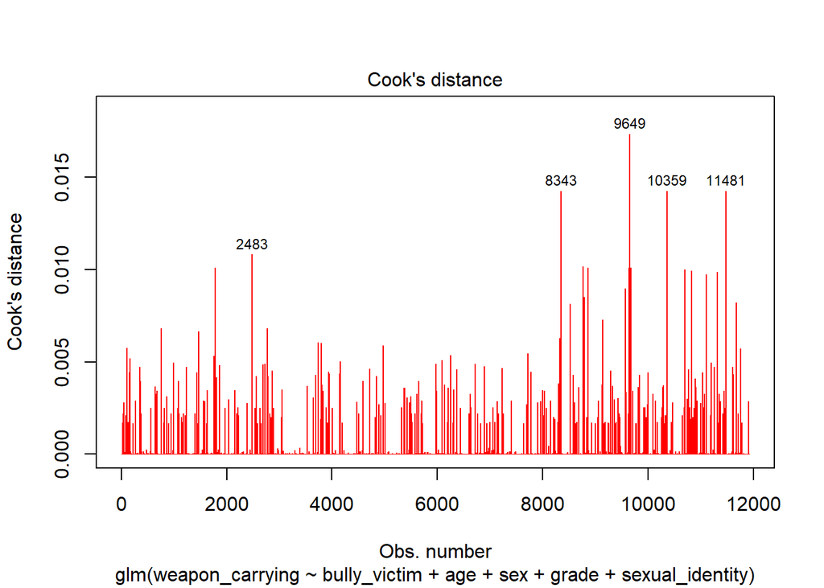

```r
#Cook's D plot
plot(confModel, which=4, id.n=5, col="red")
```

```r
#Set Cook's D cutoff=0.013
cutoff <- 0.013

#Identify observations with a Cook's Distance greater than cutoff
obs_no <- as.data.frame(cooks.distance(confModel)) %>%
  mutate(obs_no=row_number()) %>%
  filter(`cooks.distance(confModel)` > cutoff)

#Exclude the values shown in the Cook's D plot, and see how the models compare.
confModel.modex <- update(confModel,subset=c(-obs_no$obs_no))
summary(confModel.modex)
```

```
##
## Call:
## glm(formula = weapon_carrying ~ bully_victim + age + sex + grade +
##     sexual_identity, family = "binomial", data = yrbss1, subset = c(-obs_no$obs_no))
##
## Deviance Residuals:
##     Min       1Q   Median       3Q      Max
## -0.9009  -0.2321  -0.1960  -0.1277   3.2856
##
## Coefficients:
##                               Estimate Std. Error z value Pr(>|z|)
## (Intercept)                   -3.71770    1.34696  -2.760 0.005779 **
## bully_victimYes                1.13203    0.12691   8.920  < 2e-16 ***
## age                           -0.11169    0.09181  -1.217 0.223792
## sexMale                        1.20339    0.13740   8.758  < 2e-16 ***
## grade10th grade                0.58844    0.19858   2.963 0.003043 **
## grade11th grade                0.83458    0.25347   3.293 0.000993 ***
## grade12th grade                0.75609    0.32923   2.297 0.021643 *
## sexual_identityBisexual        0.86150    0.18971   4.541 5.60e-06 ***
## sexual_identityGay or lesbian  0.70845    0.28871   2.454 0.014133 *
## sexual_identityquestioning     1.27450    0.20406   6.246 4.22e-10 ***
## ---
## Signif. codes:  0 '***' 0.001 '**' 0.01 '*' 0.05 '.' 0.1 ' ' 1
##
## (Dispersion parameter for binomial family taken to be 1)
##
##     Null deviance: 2713.3  on 11916  degrees of freedom
## Residual deviance: 2516.9  on 11907  degrees of freedom
## AIC: 2536.9
##
## Number of Fisher Scoring iterations: 7
```

```r
outliers <- yrbss1[obs_no$obs_no,]

#compare coefficients between models with and without influential observations, #caveat model number of observations is not the same
compareCoefs(confModel, confModel.modex)
```

```
## Calls:
## 1: glm(formula = weapon_carrying ~ bully_victim + age + sex + grade +
##   sexual_identity, family = "binomial", data = yrbss1)
## 2: glm(formula = weapon_carrying ~ bully_victim + age + sex + grade +
##   sexual_identity, family = "binomial", data = yrbss1, subset =
##   c(-obs_no$obs_no))
##
##                               Model 1 Model 2
## (Intercept)                     -1.75   -3.72
## SE                               1.27    1.35
##
## bully_victimYes                 1.118   1.132
## SE                              0.126   0.127
##
## age                           -0.2472 -0.1117
## SE                             0.0864  0.0918
##
## sexMale                         1.213   1.203
## SE                              0.137   0.137
##
## grade10th grade                 0.726   0.588
## SE                              0.196   0.199
##
## grade11th grade                 1.134   0.835
## SE                              0.245   0.253
##
## grade12th grade                 1.165   0.756
## SE                              0.316   0.329
##
## sexual_identityBisexual         0.854   0.862
## SE                              0.189   0.190
##
## sexual_identityGay or lesbian   0.691   0.708
## SE                              0.289   0.289
##
## sexual_identityquestioning      1.293   1.274
## SE                              0.202   0.204
##
```

From the comparison results above, we can conclude that removing influential data does not largely affect the coefficient of my main exposure- bully victim (1.12 vs. 1.13).

## Model fit of the full model

```r
#Various pseudo R squares, log likelihood, deviance, AIC, BIC
blr_model_fit_stats(confModel)
```

```
##                                Model Fit Statistics
## ----------------------------------------------------------------------------------
## Log-Lik Intercept Only:     -1371.511    Log-Lik Full Model:             -1268.399
## Deviance(11911):             2536.797    LR(9):                            206.224
##                                          Prob > LR:                          0.000
## MCFadden's R2                   0.075    McFadden's Adj R2:                  0.068
## ML (Cox-Snell) R2:              0.017    Cragg-Uhler(Nagelkerke) R2:         0.083
## McKelvey & Zavoina's R2:        0.167    Efron's R2:                         0.032
## Count R2:                       0.976    Adj Count R2:                       0.000
## BIC:                         2630.658    AIC:                             2556.797
## ----------------------------------------------------------------------------------
```

```r
#Hosmer lemeshow goodness of fit test: a significant p value indicates a bad fit
blr_test_hosmer_lemeshow(confModel)
```

```
##            Partition for the Hosmer & Lemeshow Test
## --------------------------------------------------------------
##                         def = 1                 def = 0
## Group    Total    Observed    Expected    Observed    Expected
## --------------------------------------------------------------
##   1      1426        10         7.50        1416      1418.50
##   2      1321        17        10.12        1304      1310.88
##   3      1047        4          9.90        1043      1037.10
##   4      1017        12        13.83        1005      1003.17
##   5      1153        28        20.45        1125      1132.55
##   6      1459        31        31.73        1428      1427.27
##   7      1044        20        26.79        1024      1017.21
##   8      1072        32        30.08        1040      1041.92
##   9      1195        39        43.71        1156      1151.29
##  10      1187        99        97.91        1088      1089.09
## --------------------------------------------------------------
##
##      Goodness of Fit Test
## ------------------------------
## Chi-Square    DF    Pr > ChiSq
## ------------------------------
##  14.6381      8       0.0666
## ------------------------------
```

In the Hosmer & lemeshow goodness of fit test, the expected and observed frequencies match closely and the test has a non-significant p-value (0.0666) indicating that our model is a good fit.

## Full model vs. reduced model

```r
#likelihood ratio test: compare two nested models
lrtest(victimModel, confModel)
```

```
## Likelihood ratio test
##
## Model 1: weapon_carrying ~ bully_victim
## Model 2: weapon_carrying ~ bully_victim + age + sex + grade + sexual_identity
##   #Df  LogLik Df  Chisq Pr(>Chisq)
## 1   2 -1338.0
## 2  10 -1268.4  8 139.14  < 2.2e-16 ***
## ---
## Signif. codes:  0 '***' 0.001 '**' 0.01 '*' 0.05 '.' 0.1 ' ' 1
```